# DESeq2 Tutorial

### Understanding DESeq2: Dispersion

Next, we are going to take a look at our dispersion plot from our DESeq2 results. This is essentially one of DESeq’s “diagnostic” plots that shows the relationship between **gene expression strength** (average expression level of each gene) and the **natural variability across samples** (dispersion).

Let’s take a look at our dispersion plot from our DESeq2 results:

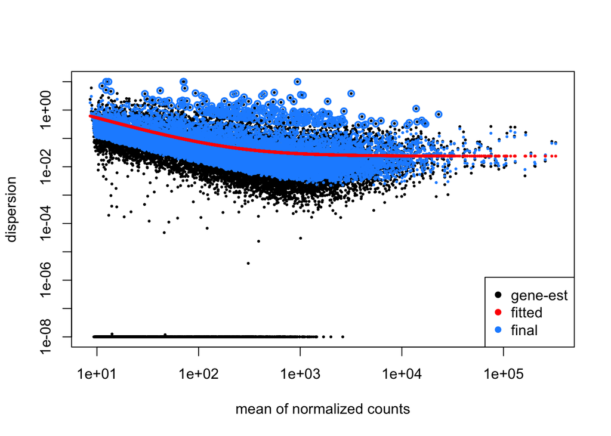

```r
plotDispEsts(test)
```

##### Axes

- **x-axis**: Mean of normalized counts
  - Think of this as **gene expression strength**, or how strongly a gene is expressed on average across all samples.
- **y-axis**: Dispersion estimate
  - This represents the **natural variability across samples** for each gene, after accounting for sequencing depth.

##### Points and Lines

- **Black dots**:
  - Each dot is a gene.
  - Its position shows the gene’s mean expression (x) and raw dispersion (y).
- **Blue points** (if present):
  - Shrunk dispersion estimates.
  - These are the stabilized values DESeq2 actually uses in statistical testing.
  - Shrinkage is especially important for genes with low counts, where sample variability is noisy.
- **Red line**:
  - A fitted trend showing the typical relationship between expression strength and variability.
  - Genes with higher expression tend to show lower variability.

#### Why this plot is useful

- It’s a **diagnostic tool** to check dispersion estimation.
- Most black dots should follow the red trend line.
- A good fit means your data are well-behaved for DESeq2’s statistical model.
- If the dots are scattered far from the line, it may point to outliers or data quality issues.

**In summary:**  
`plotDispEsts(test)` shows how **gene expression strength** relates to its **natural variability across samples**, and whether the DESeq2 model is fitting the data properly.

We can see here that our data pretty much follows the fitted trend, so we are good to continue!

- *Note*: most DE dispersion plots look something like this, so we are on the right track here!

### Visualization of DEGs: Volcano Plots

A **volcano plot** is a simple way to visualize DESeq2 results. Essentially, data points form into a volcano shaped based on these parameters:

- **x-axis**: log2 fold change (effect size; how much is that gene differentially expressed)
- **y-axis**: –log10 adjusted p-value (significance)
- Genes that are both significant and strongly differentially expressed stand out in the top left and right corners.

To plot a volcano plot with `ggplot2`, we need to first make sure our data is ready to use. To do that, we are going to firtst make the `res` DESeq results object we made before into a dataframe. Then, we will subset our dataframe to make sure that we highlight our DEGs based on their p-value.

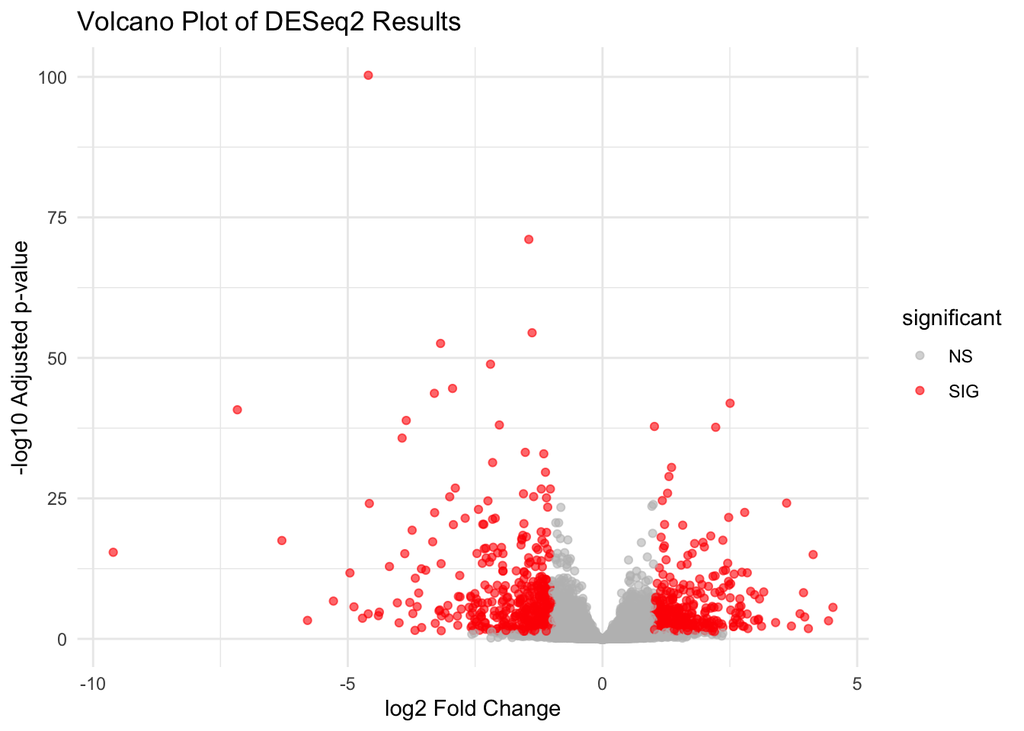

```r
# Prepare a results dataframe for plotting
res_df <- as.data.frame(res)

# Add a new column 'significant' to the data frame 'res_df'
res_df_one <- res_df %>%
  mutate(
    # 'significant' will be "SIG" if the adjusted p-value is < 0.05
    # AND the absolute value of log2 fold change is >= 1

    # Otherwise, it will be "NS" (not significant)
    significant = if_else(
      padj < 0.05 & abs(log2FoldChange) >= 1,  # condition
      "SIG",                                   # value if TRUE
      "NS"                                     # value if FALSE
    )
  ) %>%

  # remove any NAs from df_res_one (usually cells without values)
  filter(!is.na(padj) & !is.na(log2FoldChange))

# Make the volcano plot with res_df
vol1 <- ggplot(res_df_one, aes(x = log2FoldChange, y = -log10(padj), color = significant)) +
  geom_point(alpha = 0.6, size = 1.5) +
  scale_color_manual(values = c("NS" = "grey", "SIG" = "red")) +
  theme_minimal() +
  labs(title = "Volcano Plot of DESeq2 Results",
       x = "log2 Fold Change",
       y = "-log10 Adjusted p-value")

vol1
```

Do you see the volcano plot? Great work!! We see that are significant genes, but in terms of logFC (magnitude of change) and p-values (significance value) are in red, while non-significant genes are in grey. **Fantastic work everyone!! You’ve just completed one of the most important steps in transcriptomic analyses!** Pat yourselves on the back!

We aren’t done with our analysis yet though. Right now, our volcano plot highlights `SIG` genes in red—these are genes that show **both** a large log2 fold change and an adjusted p-value below 0.05. But what about genes with a very large log2 fold change whose adjusted p-value is **above** 0.05? Should we ignore them?

The answer is *no*. A high log2 fold change indicates that the gene’s expression differs substantially between our treatments (trt vs untrt), whether it is upregulated or downregulated. Even if they don’t meet the strict statistical cutoff, these genes could still be biologically meaningful. For this reason, it’s useful to define a few additional categories to capture these genes in our analysis.

#### Defining appropropriate categories

We are going to add a categorical variable that encodes four possibilities for coloring our volcano plot:

1. Not significant at all (NS)
2. Only log2FoldChange > 1 (but not significant)
3. Only padj < 0.05 (but not high logFC)
4. Both padj < 0.05 and log2FoldChange >= 1

We are first going to use piping and dyplyr again to modify our original dataframe (`res_df`):

```r
res_df_all <- res_df %>%
  mutate(
    # new column
    volcano_group = case_when(
      padj < 0.05 & abs(log2FoldChange) >= 1 ~ "Both",        # significant & large fold change
      padj < 0.05 & abs(log2FoldChange) < 1 ~ "p-value < 0.05",  # significant only
      padj >= 0.05 & abs(log2FoldChange) >= 1 ~ "LogFC > 1",     # large fold change only
      TRUE ~ "NS"                                               # not significant
    )
  ) %>%

 # remove any NAs from df_res_all (usually cells without values)
  filter(!is.na(padj) & !is.na(log2FoldChange))
```

Let’s stop here and just take a peak at the dataframe we just made:

```r
head(res_df_all)
```

```
##                   baseMean log2FoldChange      lfcSE       stat     pvalue
## ENSG00000000003  710.42002     0.38393924 0.17116713  2.2430664 0.02489253
## ENSG00000000419  521.46498    -0.19853532 0.09500465 -2.0897431 0.03664088
## ENSG00000000457  237.72210    -0.02902279 0.12239464 -0.2371246 0.81256009
## ENSG00000000460   58.07288     0.12228492 0.30991819  0.3945716 0.69315906
## ENSG00000000971 5829.69406    -0.43557919 0.25946314 -1.6787710 0.09319669
## ENSG00000001036 1285.42347     0.24713939 0.11596168  2.1312160 0.03307135
##                      padj volcano_group
## ENSG00000000003 0.1114297            NS
## ENSG00000000419 0.1465270            NS
## ENSG00000000457 0.9271215            NS
## ENSG00000000460 0.8714053            NS
## ENSG00000000971 0.2803412            NS
## ENSG00000001036 0.1368564            NS
```

We can see we have a new column on our dataframe called *volcano_group*. This will be what `ggplot2` will use to plot all of our genes according to the variables I specified earlier. The cells in this group can be:

1. “Both” (p<0.05, logFC>1)
2. “p-value < 0.05” (sig only)
3. “LogFC > 1” (large FC only)
4. “NS” (not sig and small FC)

Now that we have the data where we want it, let’s go ahead and plot it.

For the plot, I want to add **cutoff lines** to visually indicate thresholds on my figure…

- **Horizontal line**: `-log10(0.05)` → marks the significance cutoff
- **Vertical lines**: `x = -1` and `x = 1` → mark the fold-change cutoff
- These lines help quickly identify which genes fall into which category

and **assign colors** to my genes based on category:

| Category | Criteria | Color |
| --- | --- | --- |
| **NS** | Not significant | Grey |
| **LogFC > 1** | High fold change only | Blue |
| **p-value < 0.05** | Significant only | Orange |
| **Both** | High fold change & significant | Red |

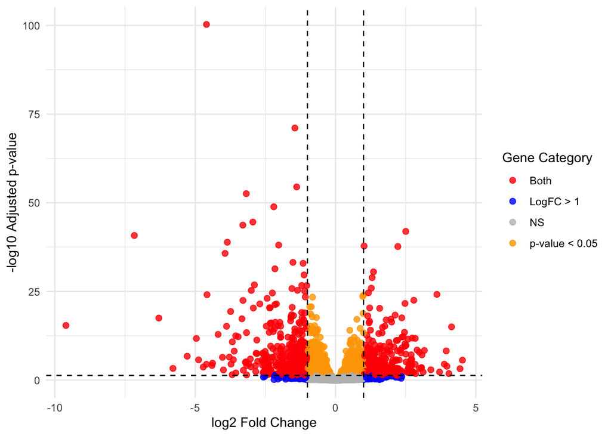

```r
# Create a volcano plot with colored categories
vol2 <- ggplot(res_df_all, aes(x = log2FoldChange, y = -log10(padj), color = volcano_group)) +

  # Add points for each gene
  geom_point(alpha = 0.8, size = 2) +
  # alpha = 0.8 makes points slightly transparent
  # size = 2 controls the point size

  # Manually assign colors to each category
  scale_color_manual(values = c(
    "NS" = "grey",
    "LogFC > 1" = "blue",
    "p-value < 0.05" = "orange",
    "Both" = "red"
  )) +

  # Add dashed horizontal line for p-value cutoff (0.05)
  geom_hline(yintercept = -log10(0.05), linetype = "dashed") +

  # Add dashed vertical lines for log2 fold-change cutoff (-1 and 1)
  geom_vline(xintercept = c(-1, 1), linetype = "dashed") +

  theme_minimal() +

  # Label axes and legend
  labs(
    x = "log2 Fold Change",
    y = "-log10 Adjusted p-value",
    color = "Gene Category"
  )

# Display the plot
vol2
```

#### Interpreting the Volcano Plot

Now, how does this volcano plot look compared to the old one we made earlier? It’s the same plot, we just can visually see a lot more information about the individual genes.

In other words, the x-axis indicates the **direction and magnitude of change** in gene expression, while the y-axis (-log10 adjusted p-value) represents **statistical significance**. Genes in the top corners of the plot (in red) are both highly differentially expressed and statistically significant.

## Congratulations!

Great job! You’ve completed the DESeq2 tutorial and learned how to create a volcano plot. This is often the first step in differential gene expression analysis, but the results you’ve generated here can serve as the foundation for many other downstream analyses.

Mastering these steps is a key part of building your skills in **comprehensive RNA-seq analysis**. Be proud of what you’ve accomplished!